# Wine Quality Exploration

#### 数据及项目简介：

#### 我们对红葡萄酒数据集进行分析

#### 这个数据集包含1,599 种红酒，以及 11 个关于酒的化学成分的变量。

#### 至少 3 名葡萄酒专家对每种酒的质量进行了评分，分数在 0（非常差）和10（非常好）之间。

#### 我们将通过分析以得知哪些化学成分影响红葡萄酒的质量

#### 变量类型概况：

```
## 'data.frame':    1599 obs. of  12 variables:
##  $ fixed.acidity       : num  7.4 7.8 7.8 11.2 7.4 7.4 7.9 7.3 7.8 7.5 ...
##  $ volatile.acidity    : num  0.7 0.88 0.76 0.28 0.7 0.66 0.6 0.65 0.58 0.5 ...
##  $ citric.acid         : num  0 0 0.04 0.56 0 0 0.06 0 0.02 0.36 ...
##  $ residual.sugar      : num  1.9 2.6 2.3 1.9 1.9 1.8 1.6 1.2 2 6.1 ...
##  $ chlorides           : num  0.076 0.098 0.092 0.075 0.076 0.075 0.069 0.065 0.073 0.071 ...
##  $ free.sulfur.dioxide : num  11 25 15 17 11 13 15 15 9 17 ...
##  $ total.sulfur.dioxide: num  34 67 54 60 34 40 59 21 18 102 ...
##  $ density             : num  0.998 0.997 0.997 0.998 0.998 ...
##  $ pH                  : num  3.51 3.2 3.26 3.16 3.51 3.51 3.3 3.39 3.36 3.35 ...
##  $ sulphates           : num  0.56 0.68 0.65 0.58 0.56 0.56 0.46 0.47 0.57 0.8 ...
##  $ alcohol             : num  9.4 9.8 9.8 9.8 9.4 9.4 9.4 10 9.5 10.5 ...
##  $ quality             : int  5 5 5 6 5 5 5 7 7 5 ...
```

#### 变量统计概况：

```
##  fixed.acidity   volatile.acidity  citric.acid    residual.sugar
##  Min.   : 4.60   Min.   :0.1200   Min.   :0.000   Min.   : 0.900
##  1st Qu.: 7.10   1st Qu.:0.3900   1st Qu.:0.090   1st Qu.: 1.900
##  Median : 7.90   Median :0.5200   Median :0.260   Median : 2.200
##  Mean   : 8.32   Mean   :0.5278   Mean   :0.271   Mean   : 2.539
##  3rd Qu.: 9.20   3rd Qu.:0.6400   3rd Qu.:0.420   3rd Qu.: 2.600
##  Max.   :15.90   Max.   :1.5800   Max.   :1.000   Max.   :15.500
##    chlorides       free.sulfur.dioxide total.sulfur.dioxide
##  Min.   :0.01200   Min.   : 1.00       Min.   :  6.00
##  1st Qu.:0.07000   1st Qu.: 7.00       1st Qu.: 22.00
##  Median :0.07900   Median :14.00       Median : 38.00
##  Mean   :0.08747   Mean   :15.87       Mean   : 46.47
##  3rd Qu.:0.09000   3rd Qu.:21.00       3rd Qu.: 62.00
##  Max.   :0.61100   Max.   :72.00       Max.   :289.00
##     density             pH          sulphates         alcohol
##  Min.   :0.9901   Min.   :2.740   Min.   :0.3300   Min.   : 8.40
##  1st Qu.:0.9956   1st Qu.:3.210   1st Qu.:0.5500   1st Qu.: 9.50
##  Median :0.9968   Median :3.310   Median :0.6200   Median :10.20
##  Mean   :0.9967   Mean   :3.311   Mean   :0.6581   Mean   :10.42
##  3rd Qu.:0.9978   3rd Qu.:3.400   3rd Qu.:0.7300   3rd Qu.:11.10
##  Max.   :1.0037   Max.   :4.010   Max.   :2.0000   Max.   :14.90
##     quality
##  Min.   :3.000
##  1st Qu.:5.000
##  Median :6.000
##  Mean   :5.636
##  3rd Qu.:6.000
##  Max.   :8.000
```

#### 我们的数据集由十二个变量组成，有1599个观测值。

# 单变量绘图选择

#### 查看酒的质量的评分分布：

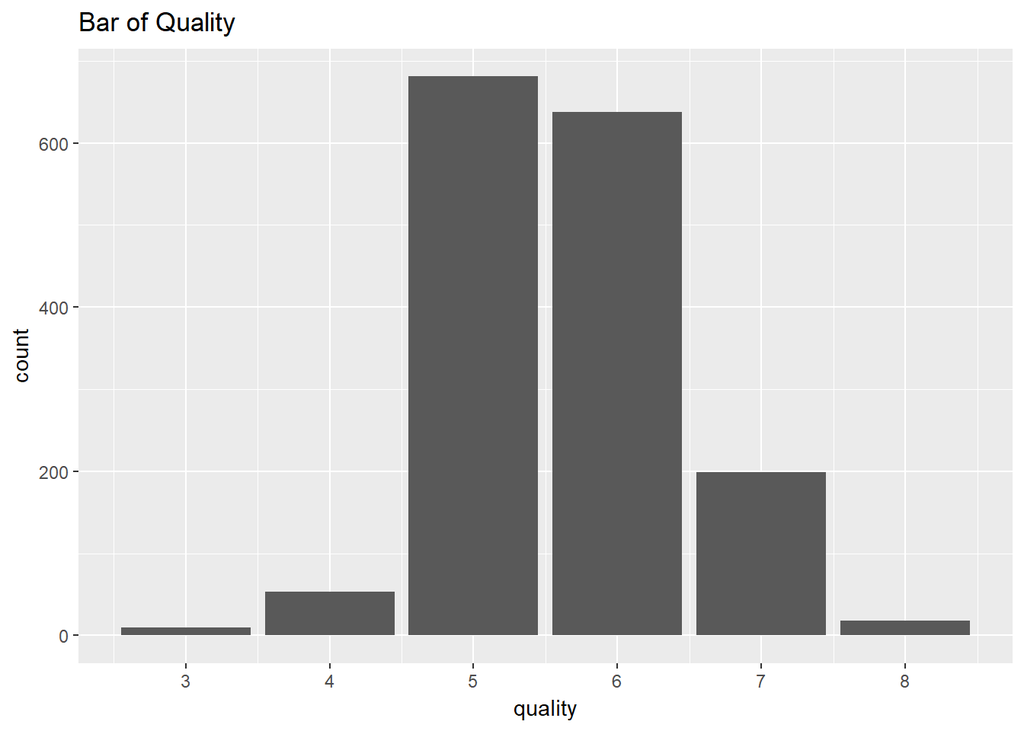

#### 从上图可以看出，质量基本呈正态分布

#### 查看fixed.acidity的分布：

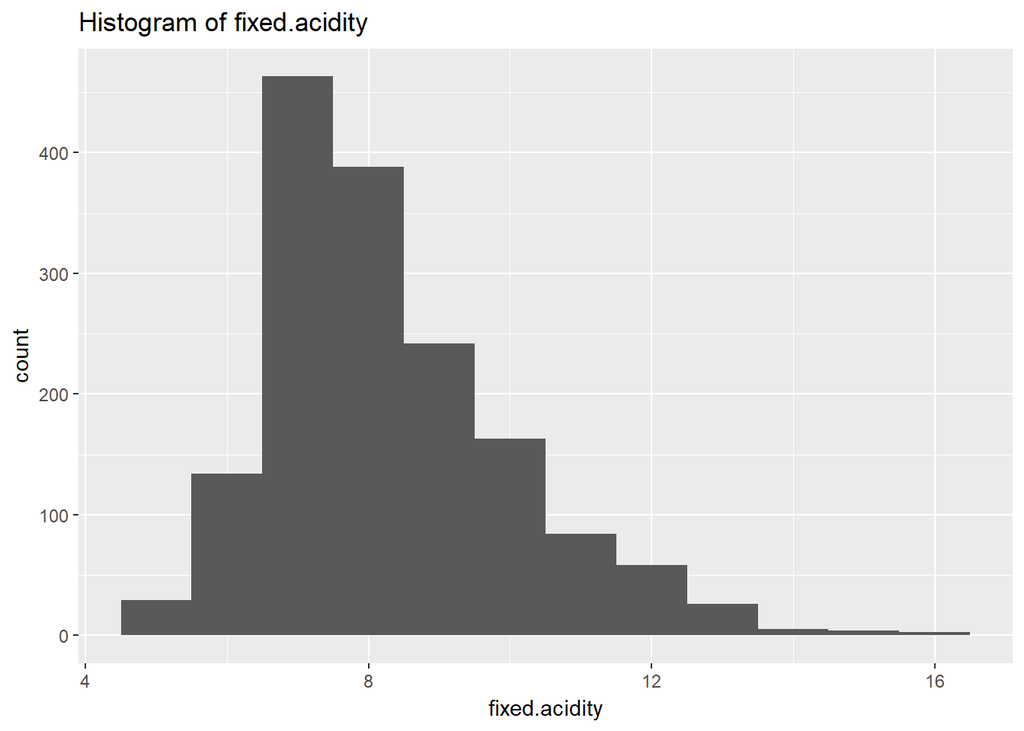

#### 上图表明fixed.acidity呈右偏分布,大多数在6~12之间。

#### 查看volatile.acidity的分布形态：

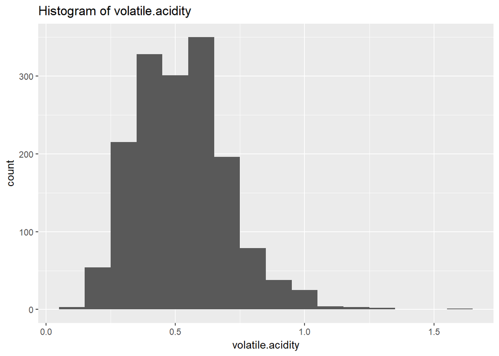

#### volatile.acidity也呈右偏分布，但其中有异常值，大多数值在0.25~1之间，我们取其前99%的数绘图：

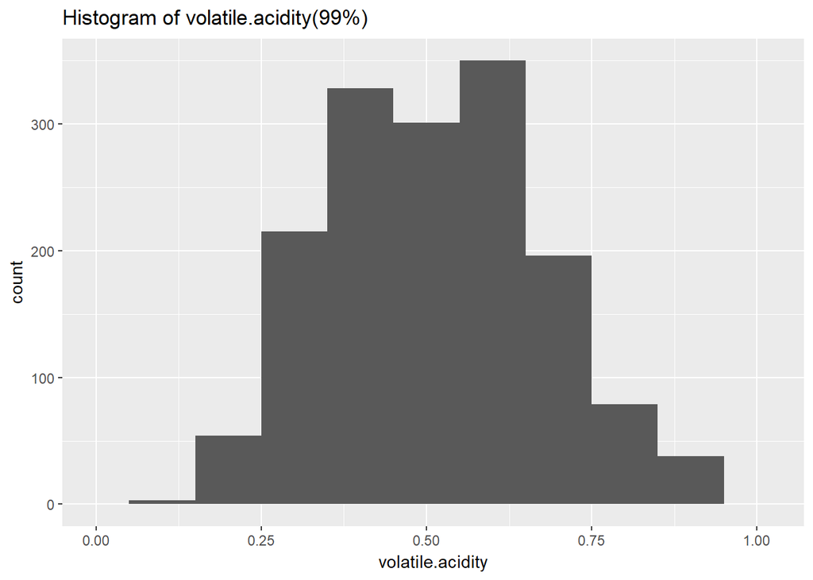

#### 上图可以看到，去掉异常值后，volatile.acidity呈正态分布。

#### 查看citric.acid的分布：

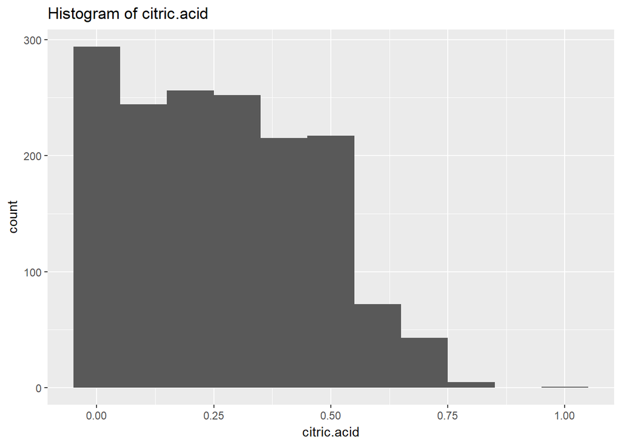

#### 查看residual.sugar的分布：

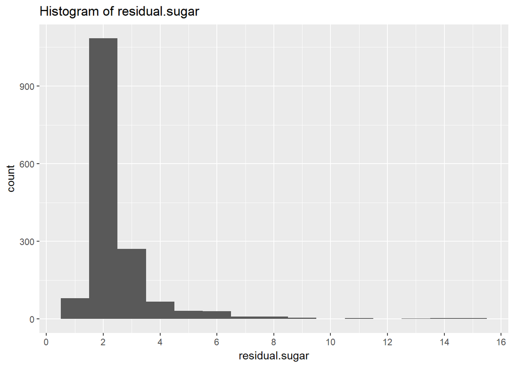

#### 上图中残糖呈长尾分布，对其取对数进行收敛：

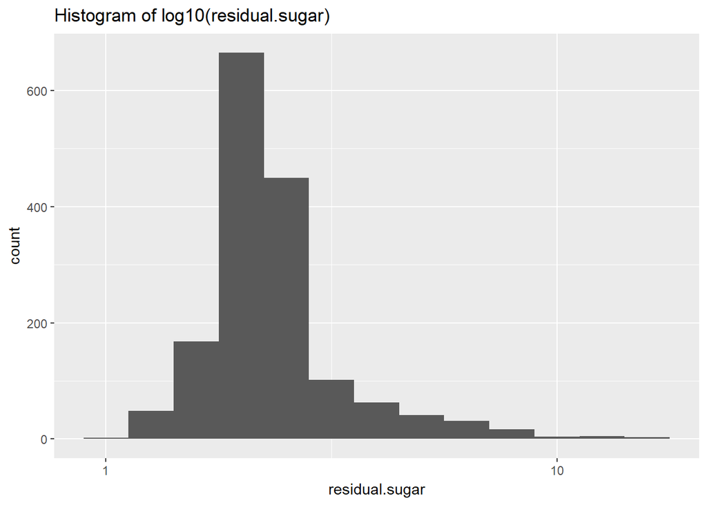

#### 收敛后的图呈右偏的正态分布

#### 查看chlorides的分布：

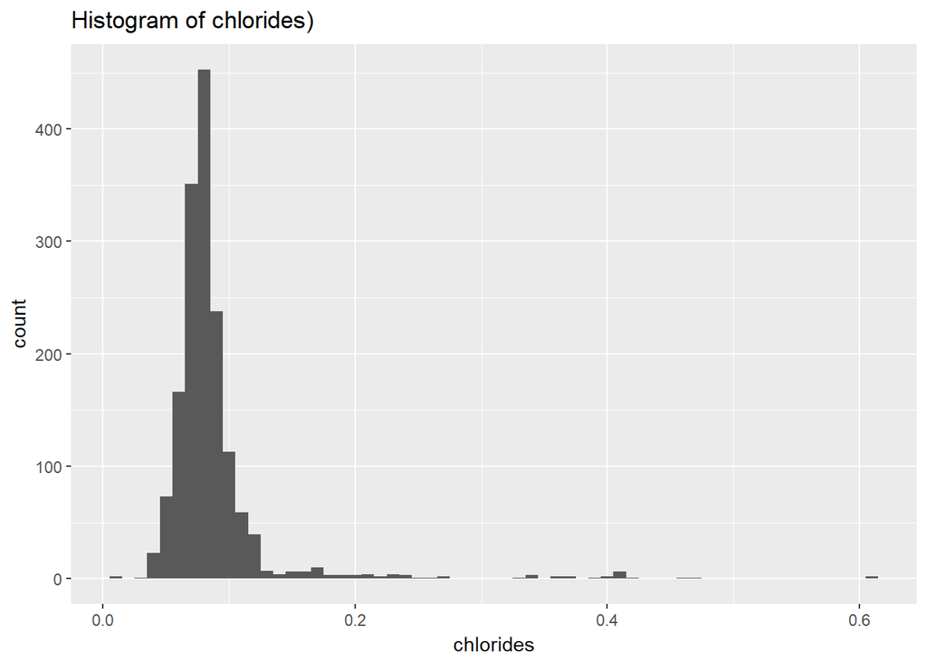

#### chlorides的大多数值分布集中，少量值严重右偏，不知是不是数据错误，取其前99%的值:

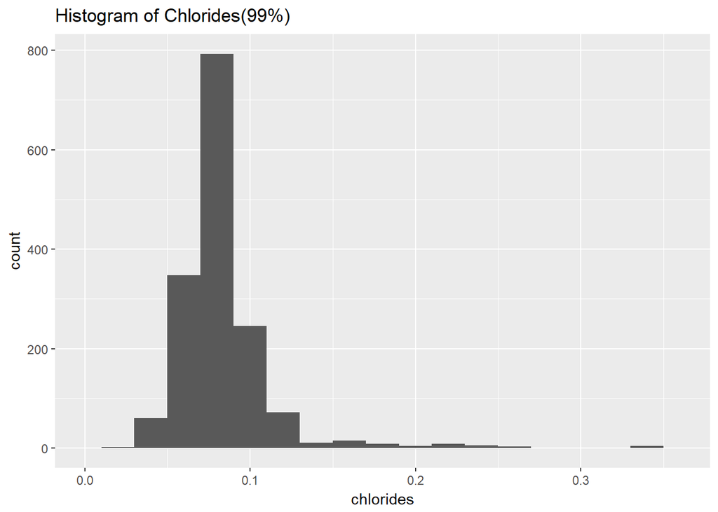

#### 转换后呈右偏正态分布

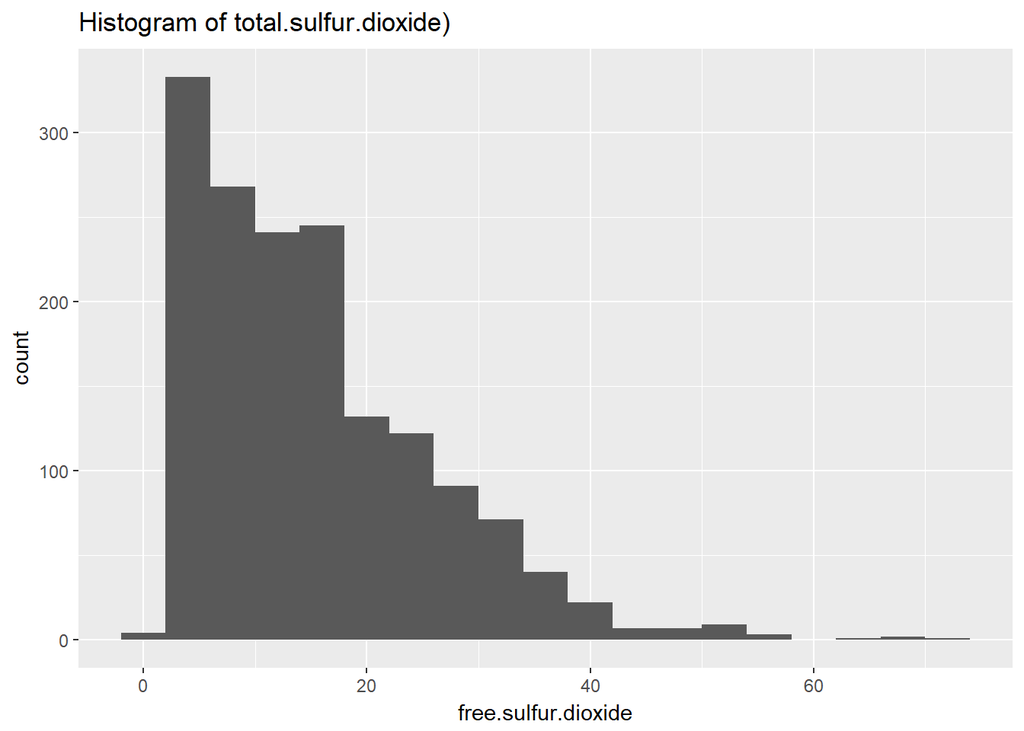

#### 查看total.sulfur.dioxide的分布：

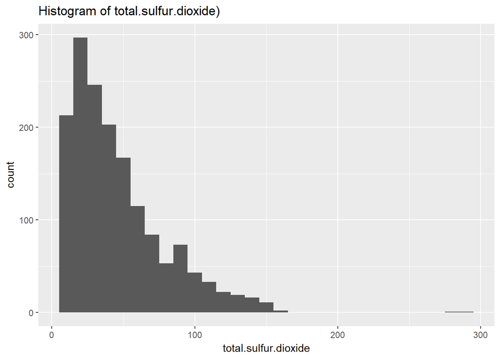

#### 上面total.sulfur.dioxide存在异常值，取其前99%的数绘制：

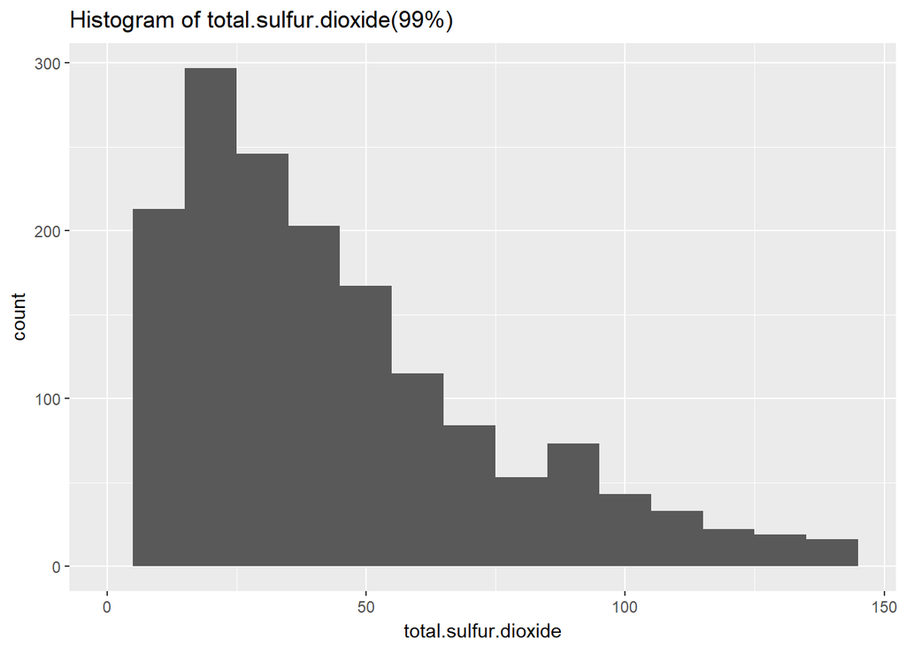

#### 去掉异常值的total.sulfur.dioxide呈长尾分布

#### 查看density的分布：

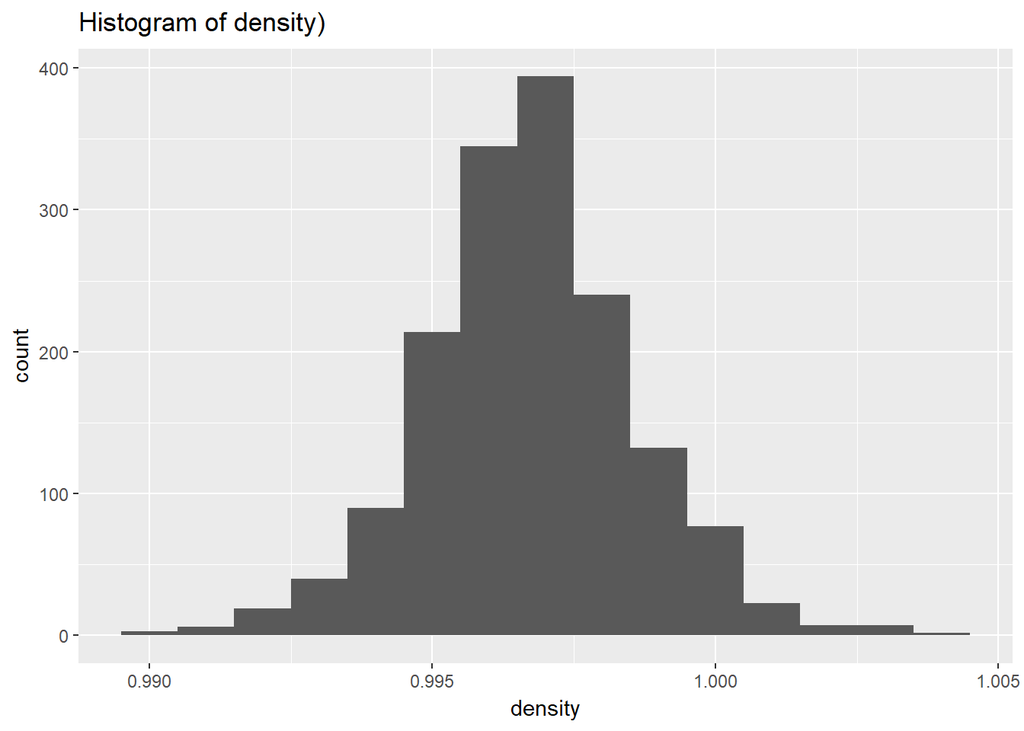

#### density基本呈标准正态分布

#### 查看PH分布：

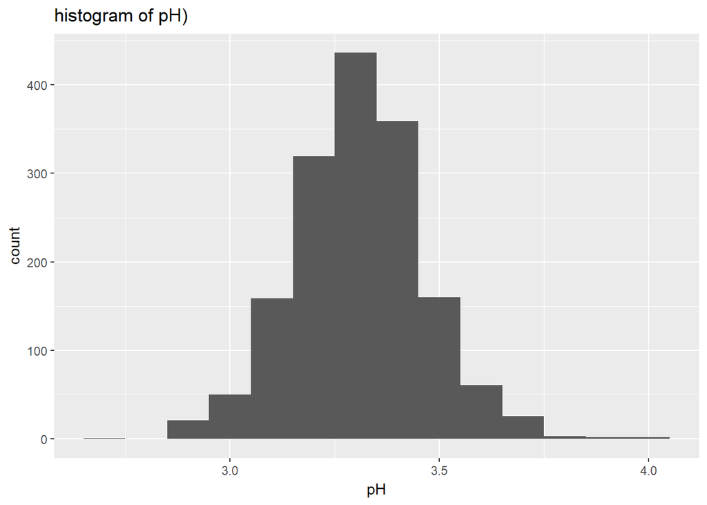

#### PH也基本呈标准正态分布

#### 查看sulphates的分布：

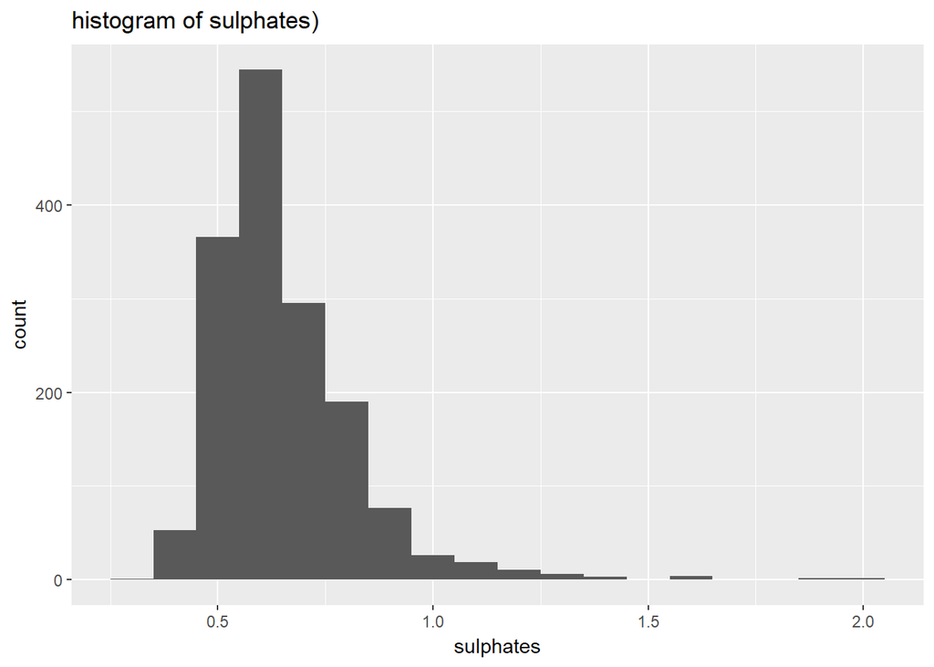

#### 上图可以看出，sulphates存在异常值，取sulphates前99%的值绘图：

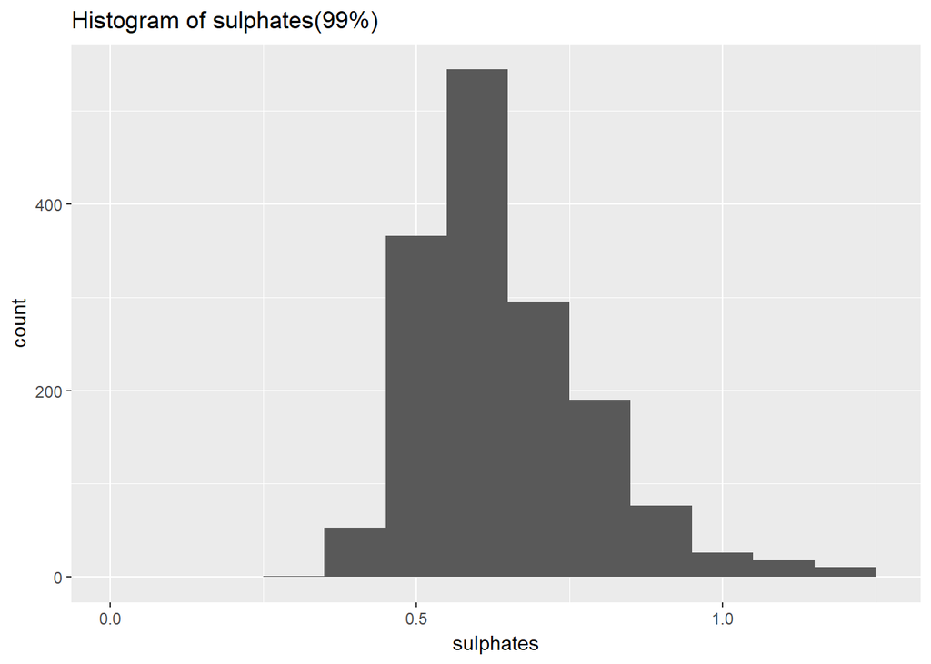

#### 去掉异常值后sulphates呈右偏正态分布，大部分值在0.5~1之间。

#### 查看alcohol的分布形态：

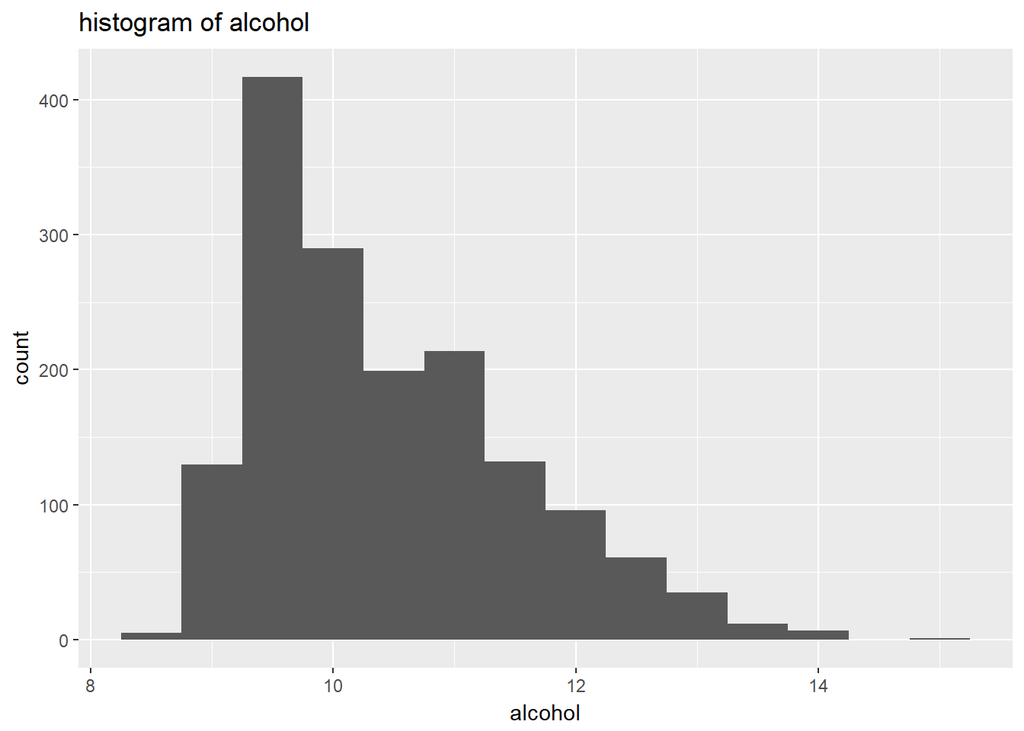

#### alcohol呈右偏正态分布

# 单变量分析

### 你的数据集结构是什么？

##### 数据集有1599个观测值，有12个特征，除了质量是整数型，其它都是浮点型。

### 你的数据集内感兴趣的主要特性有哪些？

##### 主要有质量，固定酸度，游离酸度，柠檬酸，残糖

### 你认为数据集内哪些其他特征可以帮助你探索兴趣特点？

##### 我觉得PH及酒精也有影响

### 根据数据集内已有变量，你是否创建了任何新变量？

##### 没有创建新的变量

### 在已经探究的特性中，是否存在任何异常分布？你是否对数据进行一些操作，如清洁、调整或改变数据的形式？如果是，你为什么会这样做？

##### 游离酸度有异常值，对其取前99%的数据，残糖呈现长尾分布，对其用对数转换，氯化物也是长尾分布，

# 双变量绘图选择

#### 查看fixed.acidity和quality的关系：

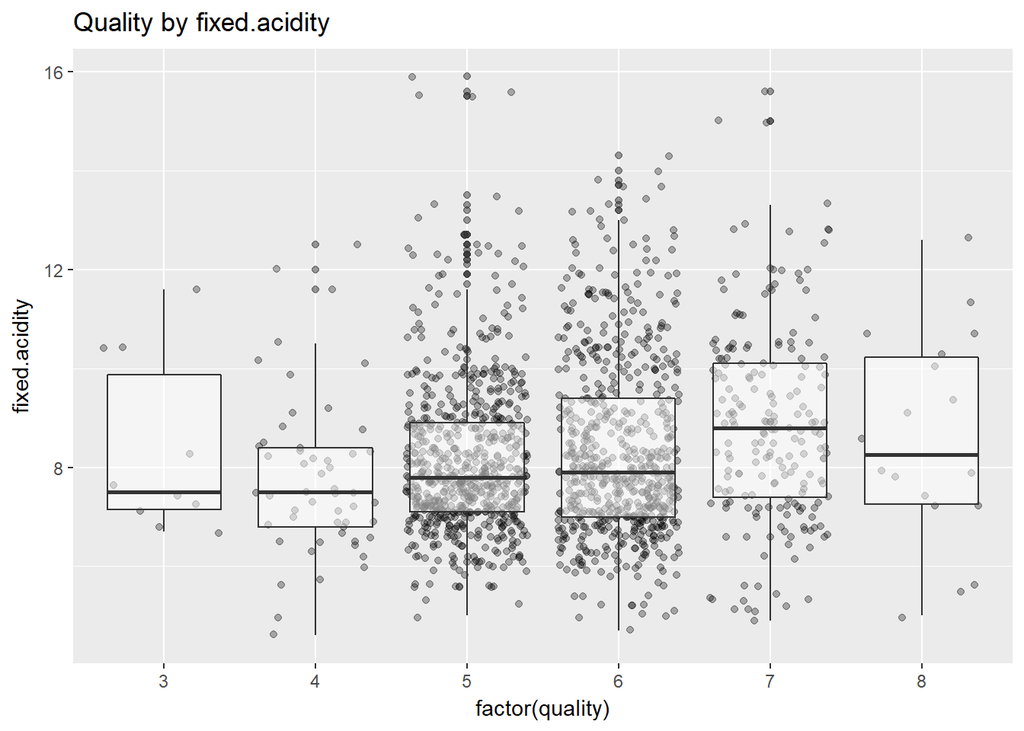

#### 从分布看，quality值的主要区间中fixed.acidity基本均匀分布，两者没有明显关系

#### 计算fixed.acidity与quality的相关性系数：

```
##
##  Pearson's product-moment correlation
##
## data:  fixed.acidity and quality
## t = 4.996, df = 1597, p-value = 6.496e-07
## alternative hypothesis: true correlation is not equal to 0
## 95 percent confidence interval:
##  0.07548957 0.17202667
## sample estimates:
##       cor
## 0.1240516
```

#### 查看volatile.acidity和quality的关系：

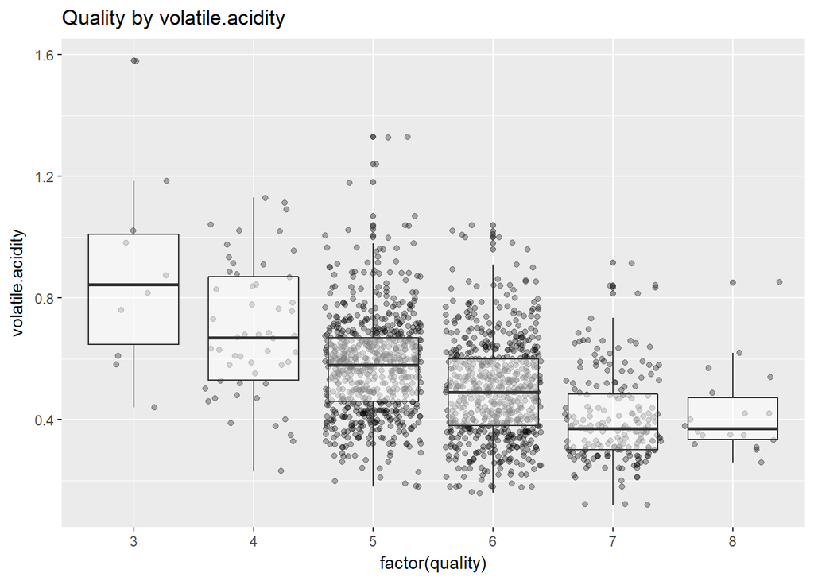

#### 从分布看，貌似呈负相关，但不明显

#### 计算volatile.acidity和quality的相关性系数：

```
##
##  Pearson's product-moment correlation
##
## data:  volatile.acidity and quality
## t = -16.954, df = 1597, p-value < 2.2e-16
## alternative hypothesis: true correlation is not equal to 0
## 95 percent confidence interval:
##  -0.4313210 -0.3482032
## sample estimates:
##        cor
## -0.3905578
```

#### volatile.acidity和quality的相关系数为-0.39，与分布的观察结果一致

#### 查看citric.acid和质量的关系：

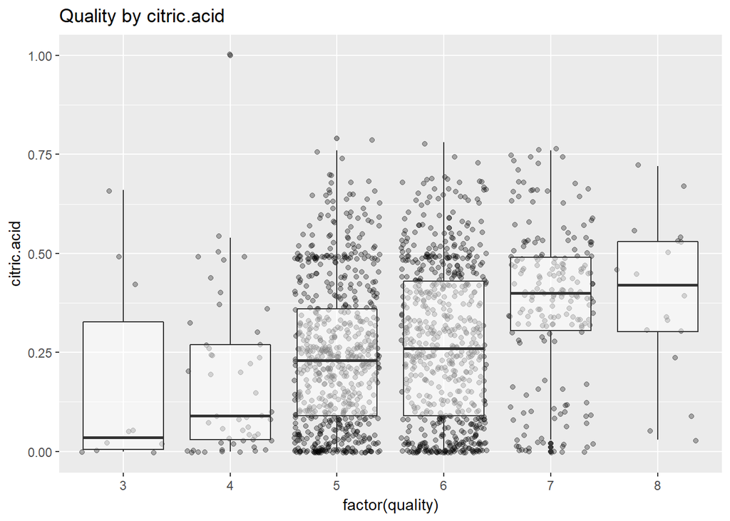

#### 计算柠檬酸与质量的相关性：

```
##
##  Pearson's product-moment correlation
##
## data:  citric.acid and quality
## t = 9.2875, df = 1597, p-value < 2.2e-16
## alternative hypothesis: true correlation is not equal to 0
## 95 percent confidence interval:
##  0.1793415 0.2723711
## sample estimates:
##       cor
## 0.2263725
```

#### 查看residual.sugar和quality的相关性：

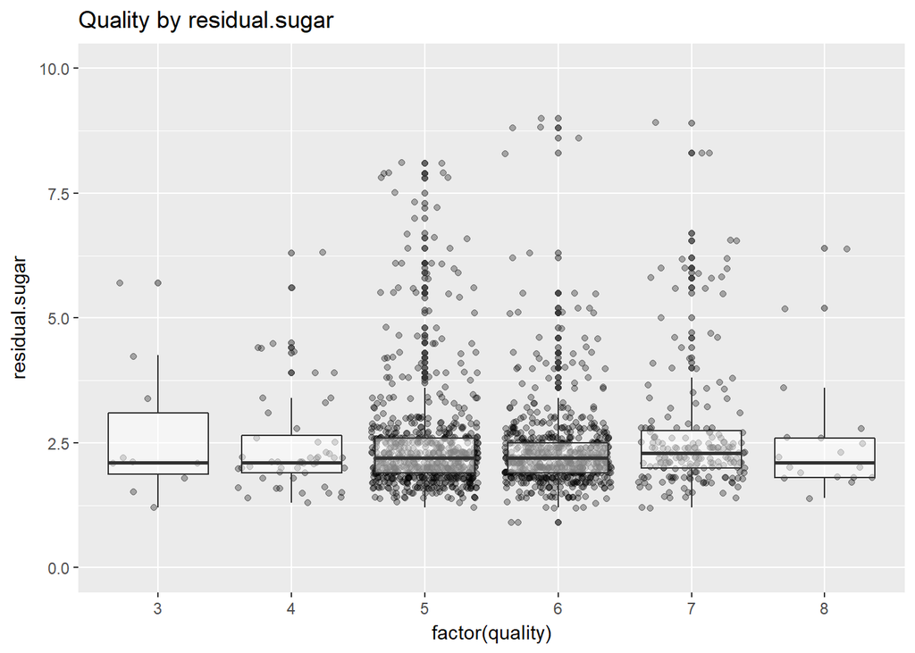

##### 残糖主要分布在质量5/6分上，没有相关性

#### 计算残糖与质量的相关性：

```
##
##  Pearson's product-moment correlation
##
## data:  residual.sugar and quality
## t = 0.5488, df = 1597, p-value = 0.5832
## alternative hypothesis: true correlation is not equal to 0
## 95 percent confidence interval:
##  -0.03531327  0.06271056
## sample estimates:
##        cor
## 0.01373164
```

#### 查看Quality和chlorides的相关性：

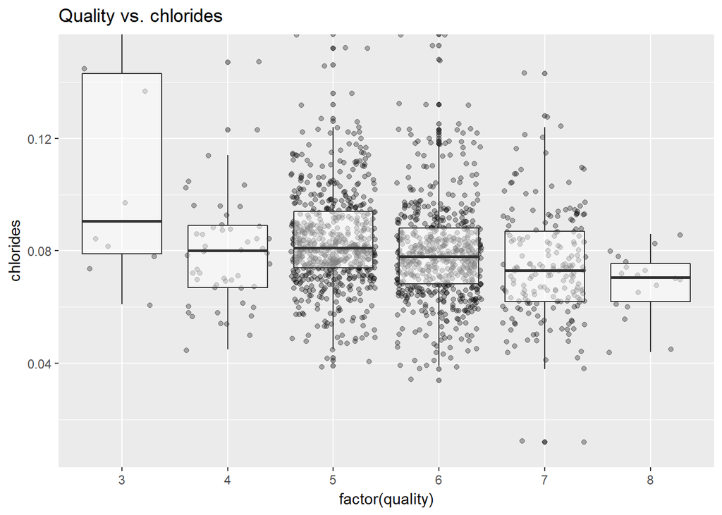

##### 看不出有相关性

#### 计算Quality和chlorides的相关性：

```
##
##  Pearson's product-moment correlation
##
## data:  chlorides and quality
## t = -5.1948, df = 1597, p-value = 2.313e-07
## alternative hypothesis: true correlation is not equal to 0
## 95 percent confidence interval:
##  -0.17681041 -0.08039344
## sample estimates:
##        cor
## -0.1289066
```

#### 查看free.sulfur.dioxide和quality的相关性：

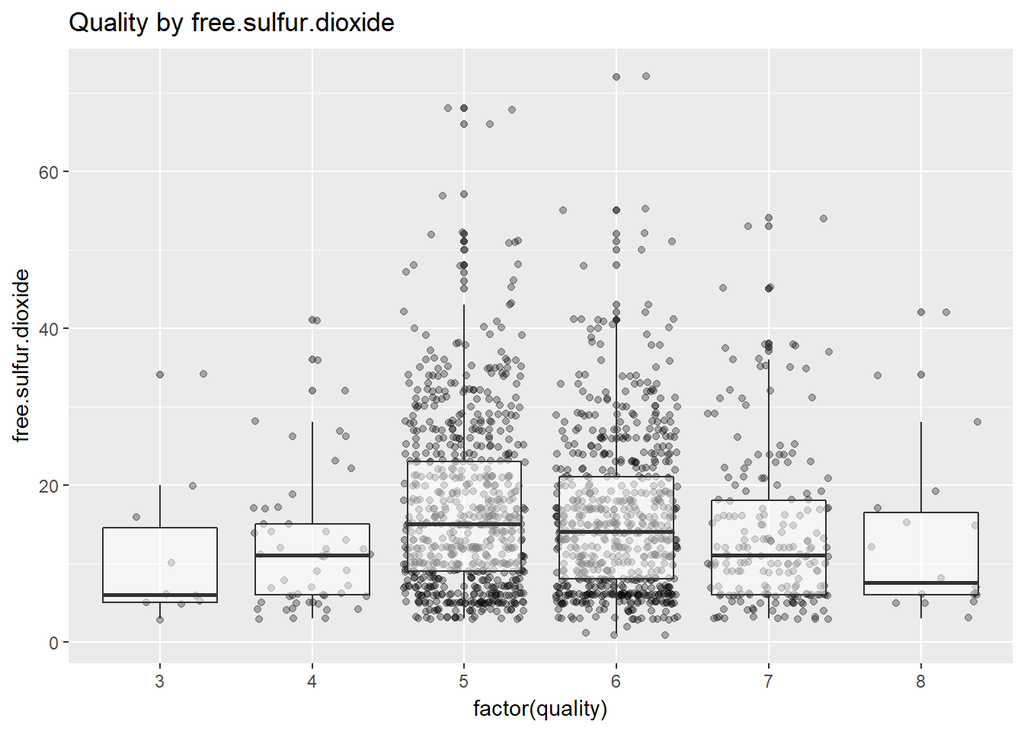

##### 明显没有相关性

#### 计算free.sulfur.dioxide和quality的相关性：

```
##
##  Pearson's product-moment correlation
##
## data:  free.sulfur.dioxide and quality
## t = -2.0269, df = 1597, p-value = 0.04283
## alternative hypothesis: true correlation is not equal to 0
## 95 percent confidence interval:
##  -0.099430290 -0.001638987
## sample estimates:
##         cor
## -0.05065606
```

#### 查看total.sulfur.dioxide和quality的相关性：

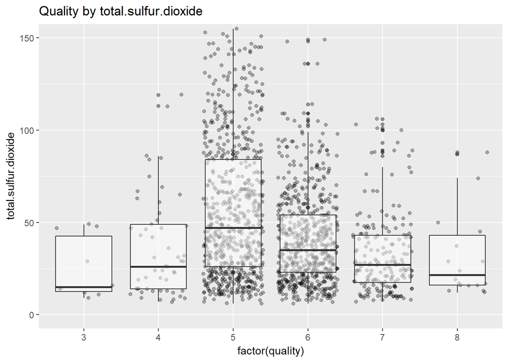

#### total.sulfur.dioxide主要分布在质量评分5~7分上面，与质量没有明显的相关性。

#### 计算total.sulfur.dioxide和quality的相关性：

```
##
##  Pearson's product-moment correlation
##
## data:  total.sulfur.dioxide and quality
## t = -7.5271, df = 1597, p-value = 8.622e-14
## alternative hypothesis: true correlation is not equal to 0
## 95 percent confidence interval:
##  -0.2320162 -0.1373252
## sample estimates:
##        cor
## -0.1851003
```

#### 查看density和quality之间的关系：

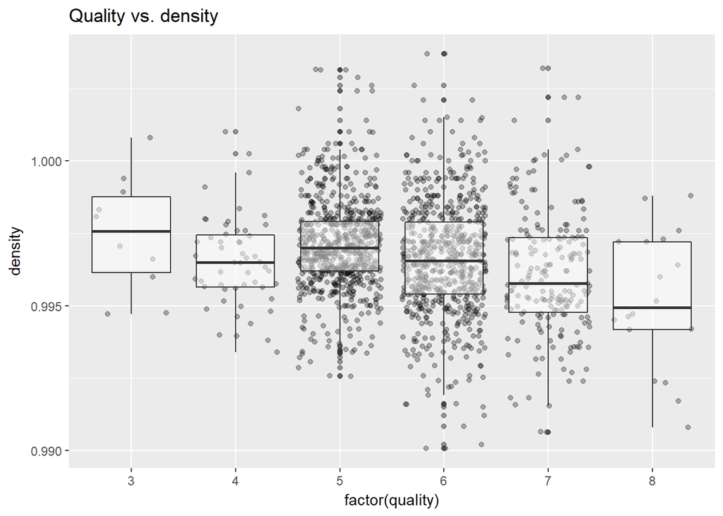

#### 密度与质量也没有明显的相关性，由于质量多集中于5~6分，散点也多位于此范围，密度基本分布均匀

#### 计算density和quality的相关系数：

```
##
##  Pearson's product-moment correlation
##
## data:  density and quality
## t = -7.0997, df = 1597, p-value = 1.875e-12
## alternative hypothesis: true correlation is not equal to 0
## 95 percent confidence interval:
##  -0.2220365 -0.1269870
## sample estimates:
##        cor
## -0.1749192
```

#### 查看pH和quality的关系：

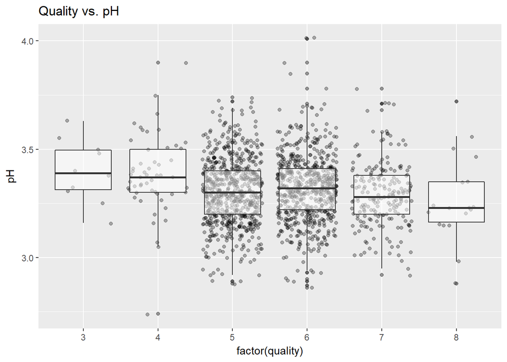

##### 看不出什么相关性

#### 计算PH与质量的相关性：

```
##
##  Pearson's product-moment correlation
##
## data:  pH and quality
## t = -2.3109, df = 1597, p-value = 0.02096
## alternative hypothesis: true correlation is not equal to 0
## 95 percent confidence interval:
##  -0.106451268 -0.008734972
## sample estimates:
##         cor
## -0.05773139
```

#### 查看alcohol和quality的相关性：

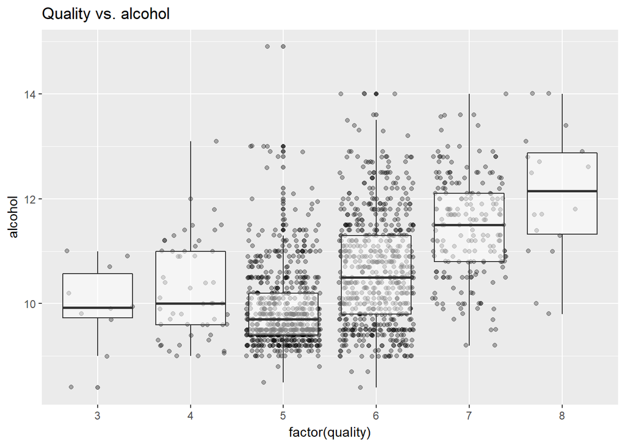

##### 看起来像正相关

#### 计算alcohol和quality的相关性：

```
##
##  Pearson's product-moment correlation
##
## data:  alcohol and quality
## t = 21.639, df = 1597, p-value < 2.2e-16
## alternative hypothesis: true correlation is not equal to 0
## 95 percent confidence interval:
##  0.4373540 0.5132081
## sample estimates:
##       cor
## 0.4761663
```

#### 绘制相关系数图：

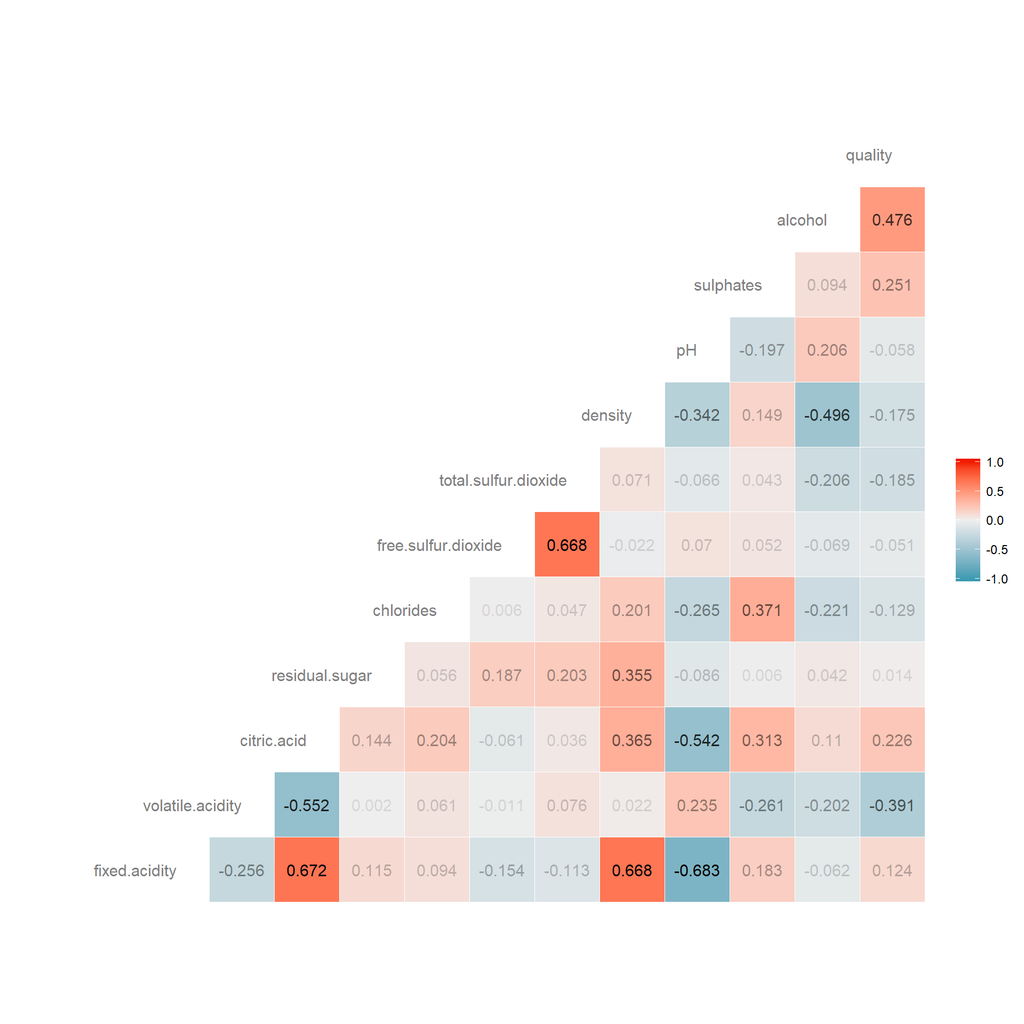

# 双变量分析

### 探讨你在这部分探究中观察到的一些关系。这些感兴趣的特性与数据集内其他特性有什么区别？

##### 质量与游离酸度及酒精度相关，而游离酸度又与柠檬酸相关，酒精度和密度相关

### 你是否观察到主要特性与其他特性之间的有趣关系？

##### 质量与游离酸度及酒精度相关

### 你发现最强的关系是什么？

# 多变量绘图选择

#### 查看citric.acid， volatile.acidity， quality间的关系：

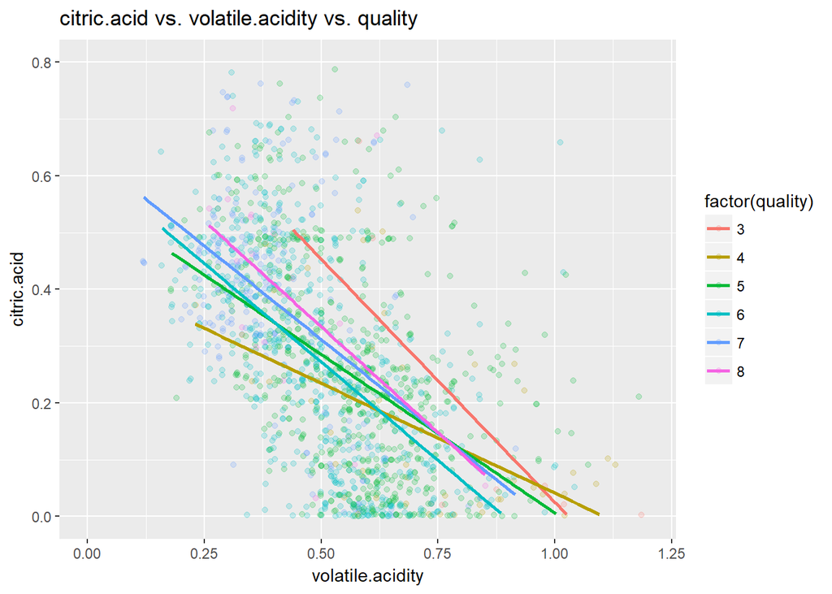

##### 不同的质量下，citric.acid和volatile.acidity成负相关，相关度为-0.55

#### 查看alcohol， pH， quality变量间的关系：

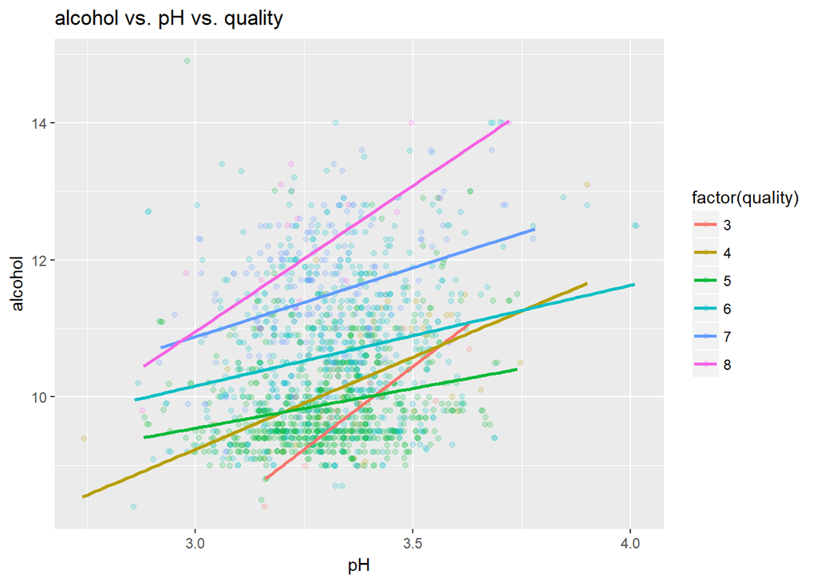

##### 不同质量下，alcohol和pH成正相关，相关度0.2，在不同质量下的相关度变化较大

#### 查看density，alcohol，quality间的关系：

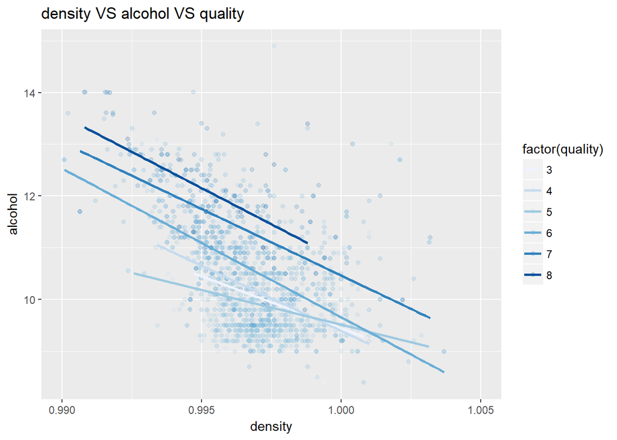

##### 不同质量下，density和alcohol呈负相关，相关系数-0.5

# 多变量分析

### 探讨你在这部分探究中观察到的一些关系。通过观察感兴趣的特性，是否存在相互促进的特性？

#### 酒精度高的质量高，与pH关系不大。

### 这些特性之间是否存在有趣或惊人的联系呢？

# 定稿图与总结

### 绘图一

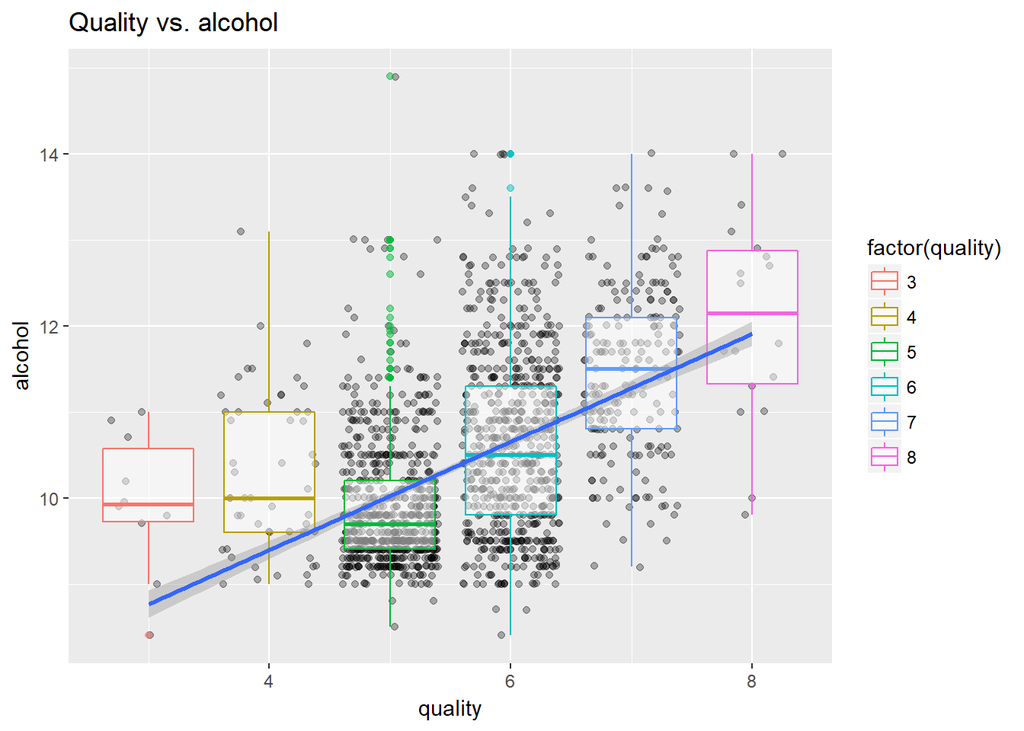